# Session 4 | Bayesian Spatial Disease Mapping in R

Queensland SA2 practical: Poisson, IID, BYM2, exceedance probabilities and uncertainty

Author

Spatial Epidemiology Course

Published

October 15, 2026

## About this practical

This practical is adapted from an Oxford teaching exercise developed by **Professor Benn Sartorius**, and uses the supplied Queensland SA2 spatial epidemiology course dataset. It takes students from data preparation and neighbour definitions to Bayesian disease mapping with **R-INLA**.

**Learning outcomes.** By the end of the session, students should be able to calculate population-based expected cases and observed-to-expected ratios; construct Queen-contiguity neighbours and an INLA graph; fit and compare Poisson, IID and BYM2 models; interpret area-level socioeconomic associations; map posterior relative risk, uncertainty and exceedance probabilities; and explain important limitations.

**Numerical reproducibility.** The reference results were produced with a particular R-INLA build. Small numerical differences between software versions are normal; unexpected changes in model rankings, risk maps or classification counts deserve checking.

**Files and workflow.** Place `QLD_SA2_Spatial_Epidemiology_Course.gpkg` in the same folder as R project. Open RStudio, set the working directory to that folder. The tutorial is designed to run **top to bottom in one fresh R session**. Fitting INLA models may take time. Outputs are saved to the working directory.

**Data interpretation warning.** The case counts in this course dataset are used for teaching. The code assumes they correspond to the provided population denominators and one consistent observation period. It does **not** adjust for age, sex, reporting differences, or temporal variation; the ratio called `SIR` in the original script is therefore not a fully age-/sex-standardised incidence ratio.

**Bayesian interpretation.** Credible intervals and exceedance probabilities are conditional on the selected likelihood, priors, adjacency graph and covariates. An ecological association is not individual-level causation.

# Section 1: Getting started

The following code checks whether the required R packages are already installed and installs only those that are missing. **R-INLA is installed from its official repository rather than CRAN.** Students can run this code when setting up their R environment for the first time. Once the packages are installed, they will simply be loaded in subsequent sessions.

```r
# Set the CRAN repository
options(repos = c(CRAN = "https://cloud.r-project.org"))

# Packages required for this tutorial
packages <- c("sf", "dplyr", "ggplot2", "spdep")

# Identify packages that are not installed
missing_packages <- packages[
  !vapply(packages, requireNamespace, logical(1), quietly = TRUE)
]

# Install only missing packages
if (length(missing_packages) > 0) {
  install.packages(missing_packages)
}

# Install INLA separately from its official repository
if (!requireNamespace("INLA", quietly = TRUE)) {

  install.packages(
    "INLA",
    repos = c(
      INLA = "https://inla.r-inla-download.org/R/stable",
      CRAN = "https://cloud.r-project.org"
    ),
    dependencies = c("Depends", "Imports", "LinkingTo")
  )
}

# Stop with a clear message if installation failed
all_packages <- c(packages, "INLA")

still_missing <- all_packages[
  !vapply(all_packages, requireNamespace, logical(1), quietly = TRUE)
]

if (length(still_missing) > 0) {
  stop(
    "These packages could not be installed: ",
    paste(still_missing, collapse = ", "),
    ". Please check the installation messages."
  )
}

# Load all packages
library(sf)
library(dplyr)
library(ggplot2)
library(spdep)
library(INLA)

# Display INLA version
packageVersion("INLA")

cat("\nAll required packages loaded successfully!\n")
```

# Section 2: Data preparation

## 2.1 Load the Queensland SA2 dataset

An **SA2 (Statistical Area Level 2)** is a geographic unit used by the Australian Bureau of Statistics. We use the supplied Queensland GeoPackage as the spatial unit of analysis. Check the feature count, column names, and geometry before modelling.

```r
# Read the GeoPackage from the current working directory
qld <- st_read("QLD_SA2_Spatial_Epidemiology_Course.gpkg", quiet = TRUE)

# Check the dataset
nrow(qld)
names(qld)
head(sf::st_drop_geometry(qld), 6)
```

**Check:** There should be **533 SA2 areas**. Each row must represent one polygonal area; its case count and population must refer to the same area and period.

**Teaching check:** The input should contain 533 SA2 polygons. Inspect the `qld` object interactively in RStudio if you need to see its complete field list. The rendered document suppresses the initial file path and verbose import details.

## 2.2 Map Queensland SA2 boundaries

A boundary map is a basic spatial-data quality check. Look for missing polygons, unexpected geographic coverage, or unusual shapes.

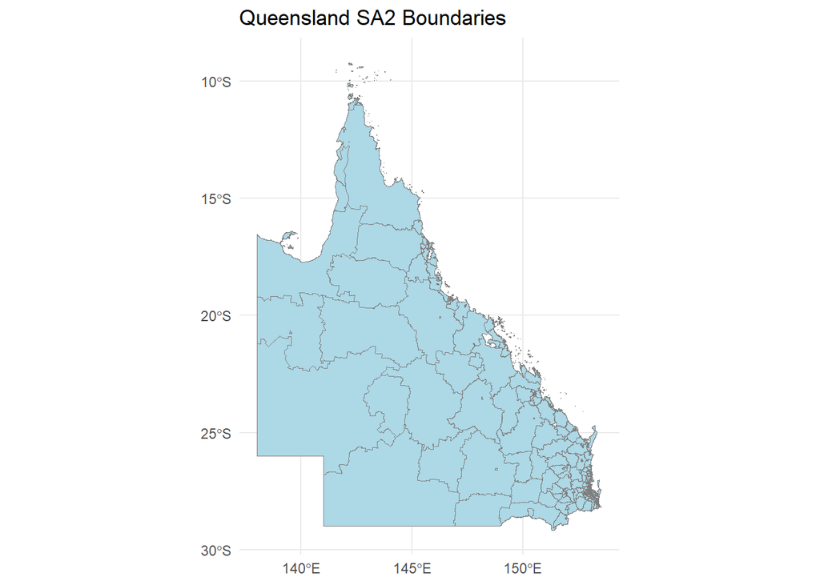

```r
print(
  ggplot(qld) +
    geom_sf(
      fill = "lightblue",
      colour = "grey50",
      linewidth = 0.1
    ) +
    labs(
      title = "Queensland SA2 Boundaries"
    ) +
    theme_minimal()
)
```

**Discuss:** Why might very large rural SA2s visually dominate a map despite having relatively small populations?

## 2.3 Summarise main variables

Inspect the distributions of case counts, populations, and the Index of Relative Socio-economic Disadvantage (IRSD). Summaries help identify skewness and implausible values.

```r
qld %>%
  st_drop_geometry() %>%
  select(CASES, POPULATION, IRSD_SCORE) %>%
  summary()
```

```
     CASES         POPULATION      IRSD_SCORE
 Min.   :  0.0   Min.   :   22   Min.   : 501.5
 1st Qu.: 24.0   1st Qu.: 6151   1st Qu.: 950.5
 Median : 36.0   Median : 9003   Median :1007.2
 Mean   : 40.1   Mean   : 9789   Mean   : 990.2
 3rd Qu.: 51.0   3rd Qu.:12388   3rd Qu.:1046.7
 Max.   :140.0   Max.   :24922   Max.   :1136.0
```

**Interpretation:** IRSD is an area-level measure, not an individual-level exposure. Associations must not be interpreted as individual-level effects.

## 2.4 Check data quality

Bayesian Poisson models require nonnegative integer case counts and positive population denominators. Missing values or zero populations can make the expected-count offset invalid.

```r
# Check missing values
colSums(
  is.na(
    st_drop_geometry(qld)[,
                          c("CASES", "POPULATION", "IRSD_SCORE")]
  )
)
```

```
     CASES POPULATION IRSD_SCORE
         0          0          0
```

```r
# Check invalid populations and case counts
sum(qld$POPULATION <= 0, na.rm = TRUE)
```

```
[1] 0
```

```r
sum(qld$CASES < 0, na.rm = TRUE)
```

```
[1] 0
```

```r
# Stop if required values are missing or invalid
if (
  anyNA(qld$CASES) ||
  anyNA(qld$POPULATION) ||
  anyNA(qld$IRSD_SCORE) ||
  any(qld$POPULATION <= 0, na.rm = TRUE) ||
  any(qld$CASES < 0, na.rm = TRUE)
) {
  stop("Missing or invalid values found in the dataset.")
}
```

**Check:** No missing values or invalid case counts/populations were found in the earlier tested data. The code stops if they appear in a new dataset.

## 2.5 Standardise socioeconomic disadvantage

Standardising IRSD subtracts its mean and divides by its standard deviation. The regression coefficient then represents a **one-standard-deviation** difference in IRSD.

```r
# Standardise IRSD score
qld$IRSD_z <- as.numeric(scale(qld$IRSD_SCORE))

# Check standardisation
summary(qld$IRSD_z)
```

```
   Min. 1st Qu.  Median    Mean 3rd Qu.    Max.
-5.7855 -0.4700  0.2014  0.0000  0.6692  1.7254
```

```r
mean(qld$IRSD_z)
```

```
[1] -2.25377e-16
```

```r
sd(qld$IRSD_z)
```

```
[1] 1
```

**Remember:** A **higher IRSD** score indicates **less socioeconomic disadvantage**. The variable name `IRSD_z` means the standardised score.

## 2.6 Calculate expected cases

The overall Queensland notification rate is total cases divided by total population. Expected cases are each SA2 population multiplied by that overall rate.

```r
# Overall disease rate
overall_rate <- sum(qld$CASES) / sum(qld$POPULATION)

# Expected cases for each SA2
qld$Expected <- qld$POPULATION * overall_rate

# Summarise expected cases
summary(qld$Expected)
```

```
     Min.   1st Qu.    Median      Mean   3rd Qu.      Max.
  0.09012  25.19596  36.87843  40.09756  50.74419 102.08643
```

**Formula:** $E_i = N_i\times (\sum_i O_i / \sum_i N_i)$. These are **population-based expected counts**; no age or sex stratification is applied.

## 2.7 Calculate observed-to-expected ratio (`SIR`)

The observed-to-expected ratio compares reported cases with the number expected at the Queensland-wide rate. A value above 1 indicates more cases than expected.

```r
# Calculate SIR
qld$SIR <- qld$CASES / qld$Expected

# Summarise SIR
summary(qld$SIR)
```

```
   Min. 1st Qu.  Median    Mean 3rd Qu.    Max.
 0.0000  0.7820  0.9787  1.0260  1.1626  2.6684
```

```r
# Display example SA2 areas
qld %>%
  st_drop_geometry() %>%
  select(SA2_NAME, CASES, POPULATION, Expected, SIR) %>%
  head()
```

```
                 SA2_NAME CASES POPULATION  Expected       SIR
1 North Stradbroke Island     6       2191  8.974856 0.6685344
2                McDowall    22       8018 32.843632 0.6698407
3   Eagle Farm - Pinkenba     6       2104  8.618484 0.6961782
4         Macgregor (Qld)    24       6075 24.884642 0.9644503
5                 Taringa    30       9188 37.636230 0.7971043
6                 Wilston    18       4089 16.749515 1.0746580
```

**Terminology correction:** The original variable name `SIR` is retained so the subsequent code still works, but the expected count is calculated as `POPULATION × overall crude rate`. Consequently, this is a **population-based observed-to-expected ratio**, not an age-/sex-standardised incidence ratio. An age-standardised SIR would require age-specific (and possibly sex-specific) reference rates and population strata. A value of 1 means observed and expected counts are equal under the crude-rate reference.

## 2.8 Map observed-to-expected ratio (`SIR`)

This map shows geographic variation in crude observed-to-expected ratios. Small areas with few expected cases may show unstable extreme ratios.

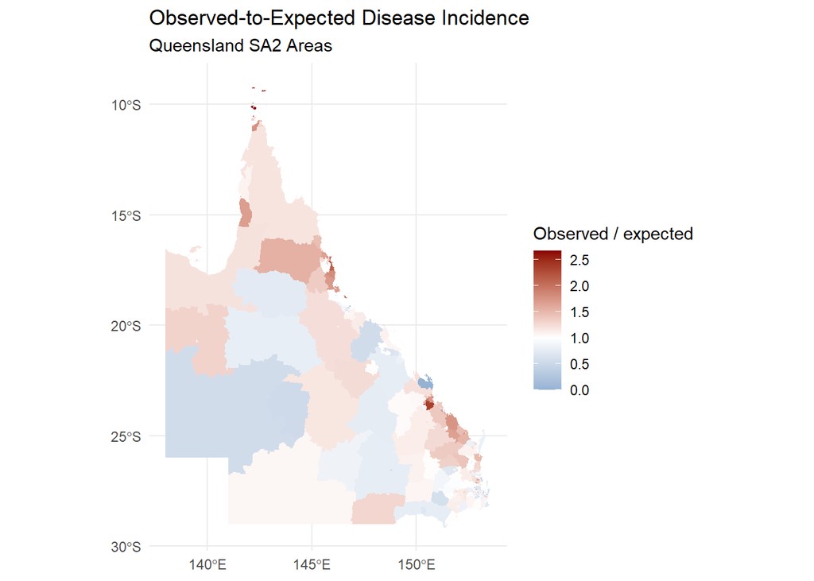

```r
print(
  ggplot(qld) +
    geom_sf(aes(fill = SIR), colour = NA) +
    scale_fill_gradient2(
      low = "steelblue",
      mid = "white",
      high = "darkred",
      midpoint = 1,
      name = "Observed / expected"
    ) +
    labs(
      title = "Observed-to-Expected Disease Incidence",
      subtitle = "Queensland SA2 Areas"
    ) +
    theme_minimal()
)
```

**Question:** Does a dark-red polygon necessarily represent strong evidence of elevated risk? Why not?

## 2.9 Validate expected cases

Because expected cases are calculated from the same overall observed rate, their sum should equal the total observed cases (up to floating-point rounding).

```r
total_observed <- sum(qld$CASES)
total_expected <- sum(qld$Expected)

total_observed
```

```
[1] 21372
```

```r
total_expected
```

```
[1] 21372
```

```r
total_observed / total_expected
```

```
[1] 1
```

```r
# Save prepared dataset
saveRDS(qld, "QLD_SA2_Session4_Prepared.rds")
```

**Expected:** Approximately **21,372 observed cases** and **21,372 expected cases**, with a total observed/expected ratio of 1.

# Section 3: Spatial neighbourhood structure

## 3.1 Create Queen contiguity neighbours

Queen contiguity defines neighbours as polygons sharing either a border segment **or a vertex**. The resulting neighbour list supplies the spatial structure used by BYM2.

```r
# Create Queen contiguity neighbour list
qld_nb <- poly2nb(
  qld,
  queen = TRUE
)

# Display neighbourhood summary
summary(qld_nb)
```

```
Neighbour list object:
Number of regions: 533
Number of nonzero links: 2666
Percentage nonzero weights: 0.9384383
Average number of links: 5.001876
7 regions with no links:
1, 17, 87, 392, 418, 495, 507
8 disjoint connected subgraphs
Link number distribution:

  0   1   2   3   4   5   6   7   8   9  10  11  13
  7  17  29  61  93 120  88  67  33  11   3   3   1
17 least connected regions:
59 67 245 248 250 257 272 310 334 356 368 379 425 490 492 494 528 with 1 link
1 most connected region:
477 with 13 links
```

**Contrast:** Rook contiguity requires a shared border segment. Neighbour definitions are modelling choices, not properties of the disease.

## 3.2 Examine number of neighbours

Counting neighbours reveals geographic differences in connectivity and areas that have no land-border neighbour.

```r
# Count neighbours for each SA2
qld$N_NEIGHBOURS <- card(qld_nb)

# Summarise neighbours
summary(qld$N_NEIGHBOURS)
```

```
   Min. 1st Qu.  Median    Mean 3rd Qu.    Max.
  0.000   4.000   5.000   5.002   6.000  13.000
```

```r
# Average number of neighbours
mean(qld$N_NEIGHBOURS)
```

```
[1] 5.001876
```

```r
# Number of isolated SA2 areas
sum(qld$N_NEIGHBOURS == 0)
```

```
[1] 7
```

```r
# List isolated SA2 areas
qld %>%
  st_drop_geometry() %>%
  filter(N_NEIGHBOURS == 0) %>%
  select(SA2_CODE, SA2_NAME, N_NEIGHBOURS)
```

```
   SA2_CODE                     SA2_NAME N_NEIGHBOURS
1 301021550      North Stradbroke Island            0
2 315011402        Torres Strait Islands            0
3 301021551 Southern Moreton Bay Islands            0
4 313011363                Bribie Island            0
5 313051574               Moreton Island            0
6 318011466                  Palm Island            0
7 318021483              Magnetic Island            0
```

**Expected:** **Seven isolated SA2s** in the tested dataset, including island areas. A warning about disconnected regions is anticipated; it should prompt inspection of the graph, not automatic modification of the data.

## 3.3 Identify connected components

A connected component is a group of areas joined by paths through the neighbour graph. Disconnected areas matter because structured spatial effects cannot borrow information across components.

```r
# Identify disconnected groups
components <- n.comp.nb(qld_nb)

# Number of components
components$nc
```

```
[1] 8
```

```r
# Size of each component
table(components$comp.id)
```

```
  1   2   3   4   5   6   7   8
  1 526   1   1   1   1   1   1
```

```r
# Add component ID
qld$COMPONENT <- components$comp.id
```

**Expected:** **Eight components**: one main group of 526 areas and seven singleton areas. Warnings about disconnected components are expected for this geography, not evidence that the analysis has failed. Each of the seven singleton areas has no Queen-contiguity neighbour. The BYM2 structured effect cannot borrow spatial information across these disconnected components; the model still uses the area’s own observations, covariate information and its unstructured component. Do not connect islands artificially just to eliminate the warning.

## 3.4 Map number of neighbours

Map the number of neighbours to see where the spatial graph is dense or sparse. Boundary and island areas often have fewer neighbours.

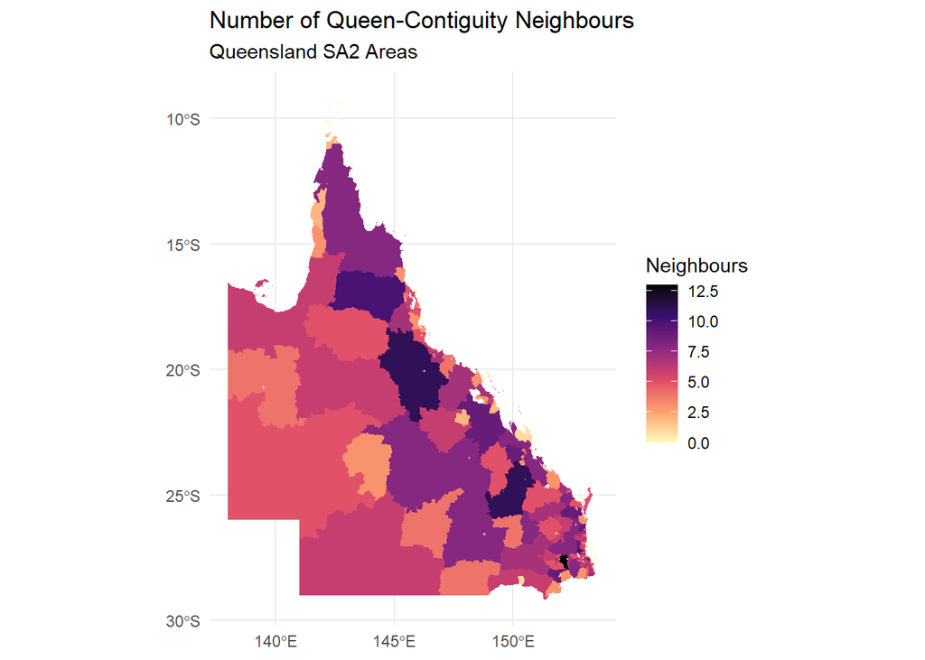

```r
print(
  ggplot(qld) +
    geom_sf(
      aes(fill = N_NEIGHBOURS),
      colour = NA
    ) +
    scale_fill_viridis_c(
      option = "magma",
      direction = -1,
      name = "Neighbours"
    ) +
    labs(
      title = "Number of Queen-Contiguity Neighbours",
      subtitle = "Queensland SA2 Areas"
    ) +
    theme_minimal()
)
```

**Question:** How might a small number of neighbours affect the precision of a spatial random effect?

## 3.5 Map isolated SA2 areas

The island map highlights the seven areas with no Queen-contiguity neighbours.

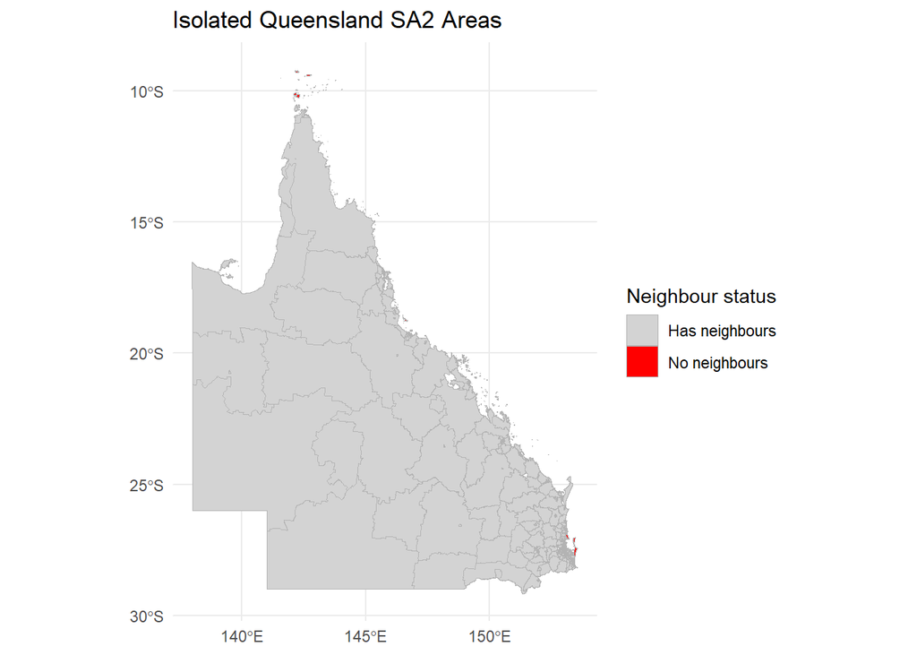

```r
# Identify isolated areas
qld$ISOLATED <- ifelse(
  qld$N_NEIGHBOURS == 0,
  "No neighbours",
  "Has neighbours"
)

# Create map
print(
  ggplot(qld) +
    geom_sf(
      aes(fill = ISOLATED),
      colour = "grey70",
      linewidth = 0.05
    ) +
    scale_fill_manual(
      values = c(
        "Has neighbours" = "lightgrey",
        "No neighbours" = "red"
      ),
      name = "Neighbour status"
    ) +
    labs(
      title = "Isolated Queensland SA2 Areas"
    ) +
    theme_minimal()
)
```

**Interpretation:** An isolated area can still be modelled, but it has no adjacent polygons from which to borrow structured spatial information. This does not mean its relative risk is unestimable: the likelihood, fixed effects and unstructured component still contribute. Keep the true neighbourhood structure rather than adding artificial connections.

## 3.6 Create binary adjacency matrix

A binary adjacency matrix has a 1 for a neighbouring pair and 0 otherwise. For an undirected Queen-contiguity graph it should be symmetric.

```r
# Convert neighbour list into binary adjacency matrix
qld_mat <- nb2mat(
  qld_nb,
  style = "B",
  zero.policy = TRUE
)

# Check matrix dimensions
dim(qld_mat)
```

```
[1] 533 533
```

```r
# Check symmetry
isSymmetric(qld_mat)
```

```
[1] TRUE
```

```r
# Display part of matrix
qld_mat[1:10, 1:10]
```

```
   1 2 3 4 5 6 7 8 9 10
1  0 0 0 0 0 0 0 0 0  0
2  0 0 0 0 0 0 0 0 0  0
3  0 0 0 0 0 0 0 0 0  0
4  0 0 0 0 0 0 0 0 0  0
5  0 0 0 0 0 0 0 0 0  0
6  0 0 0 0 0 0 0 0 0  0
7  0 0 0 0 0 0 0 0 0  0
8  0 0 0 0 0 0 0 0 0  0
9  0 0 0 0 0 0 0 0 0  0
10 0 0 0 0 0 0 0 0 0  0
```

**Expected:** A **533 × 533** symmetric matrix. The diagonal is zero because an area is not its own neighbour.

## 3.7 Visualise neighbour network

The neighbour-network plot draws connections between representative points in neighbouring polygons. The polygons are projected to Australian Albers (EPSG:3577) for a suitable Australian planar display.

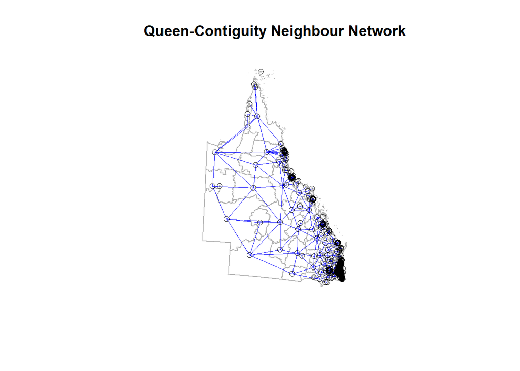

```r
# Project to Australian Albers
qld_proj <- st_transform(qld, 3577)

# Generate points inside polygons
qld_points <- st_point_on_surface(qld_proj)

# Extract coordinates
coords <- st_coordinates(qld_points)

# Plot polygons
plot(
  st_geometry(qld_proj),
  col = "white",
  border = "grey70",
  main = "Queen-Contiguity Neighbour Network"
)

# Add neighbour connections
plot(
  qld_nb,
  coords,
  add = TRUE,
  col = "blue",
  lwd = 0.5
)
```

**Note:** The points are placed on polygon surfaces for display; they are not necessarily geographic centroids.

## 3.8 Create INLA spatial graph

INLA uses an adjacency graph to represent which areas are neighbours. The graph must have the same number of nodes **and identical row order** as the modelling dataset.

```r
# Convert neighbour list to an INLA adjacency file
spdep::nb2INLA(
  "QLD_SA2_Adjacency.adj",
  qld_nb
)

# Read the adjacency file into INLA
qld_graph <- INLA::inla.read.graph(
  filename = "QLD_SA2_Adjacency.adj"
)

# Check graph size without printing the complete neighbour list
qld_graph$n
```

```
[1] 533
```

```r
# Confirm graph size matches number of SA2 areas
stopifnot(qld_graph$n == nrow(qld))
```

**Important:** Reordering SA2 rows after constructing the graph would silently attach neighbourhood relationships to the wrong areas.

## 3.9 Create random effect identifiers

Random-effect identifiers link each SA2 to its latent spatial and non-spatial effect. Each area receives a unique integer index.

```r
# Structured spatial random effect
qld$id.u <- seq_len(nrow(qld))

# Unstructured random effect
qld$id.v <- seq_len(nrow(qld))

# Check identifiers
qld %>%
  st_drop_geometry() %>%
  select(SA2_NAME, id.u, id.v) %>%
  head()
```

```
                 SA2_NAME id.u id.v
1 North Stradbroke Island    1    1
2                McDowall    2    2
3   Eagle Farm - Pinkenba    3    3
4         Macgregor (Qld)    4    4
5                 Taringa    5    5
6                 Wilston    6    6
```

**Note:** The original `id.u` and `id.v` fields are retained as a teaching illustration; Section 4 uses `IID_ID` and `BYM2_ID`.

## 3.10 Save objects for Bayesian modelling

Save intermediate data, neighbours, matrix, and graph so the analysis can be inspected or resumed without rebuilding the spatial objects.

```r
saveRDS(
  qld,
  "QLD_SA2_Session4_Spatial_Prepared.rds"
)

saveRDS(
  qld_nb,
  "QLD_SA2_Session4_Neighbours.rds"
)

saveRDS(
  qld_mat,
  "QLD_SA2_Session4_Adjacency_Matrix.rds"
)

saveRDS(
  qld_graph,
  "QLD_SA2_Session4_INLA_Graph.rds"
)
```

**Teaching point:** Saving an RDS object preserves its R structure; GeoPackage is more convenient for GIS software.

## 3.11 Final summary

Review the spatial-data preparation summary before fitting any Bayesian model.

```r
cat("\n====================================\n")
cat("SECTIONS 2 AND 3 COMPLETED\n")
```

```
SECTIONS 2 AND 3 COMPLETED
```

```r
cat("====================================\n")
cat("Number of SA2 areas:", nrow(qld), "\n")
```

```
Number of SA2 areas: 533
```

```r
cat("Total observed cases:", total_observed, "\n")
```

```
Total observed cases: 21372
```

```r
cat("Total expected cases:", round(total_expected, 2), "\n")
```

```
Total expected cases: 21372
```

```r
cat(
  "Average number of neighbours:",
  round(mean(qld$N_NEIGHBOURS), 2),
  "\n"
)
```

```
Average number of neighbours: 5
```

```r
cat(
  "Number of isolated SA2 areas:",
  sum(qld$N_NEIGHBOURS == 0),
  "\n"
)
```

```
Number of isolated SA2 areas: 7
```

```r
cat(
  "Number of connected components:",
  components$nc,
  "\n"
)
```

```
Number of connected components: 8
```

```r
cat(
  "INLA graph contains:",
  qld_graph$n,
  "areas\n"
)
```

```
INLA graph contains: 533 areas
```

```r
cat("\nReady for Bayesian spatial modelling!\n")
```

```
Ready for Bayesian spatial modelling!
```

**Expected:** 533 areas, seven isolated areas, and eight graph components.

# Section 4: Bayesian Poisson and BYM2 models

We model observed counts with expected cases as the exposure, compare three increasingly flexible models, and examine spatial smoothing.

## 4.2 Check prepared data and spatial graph

Keep the **same `qld` row order** as the graph created in Section 3. The model uses integer identifiers to associate one random effect with each SA2.

```r
# Continue with the qld object prepared in Sections 2–3.
# Its row order must match the adjacency graph.
stopifnot(nrow(qld) == qld_graph$n)

qld$AREA_ID <- seq_len(nrow(qld))
qld$IID_ID <- seq_len(nrow(qld))
qld$BYM2_ID <- seq_len(nrow(qld))

stopifnot(
  all(!is.na(qld$CASES)),
  all(qld$CASES >= 0),
  all(qld$CASES == floor(qld$CASES)),
  all(is.finite(qld$Expected)),
  all(qld$Expected > 0),
  all(is.finite(qld$IRSD_z))
)

isolated <- which(qld_graph$nnbs == 0)
cat("Number of SA2 areas:", nrow(qld), "\n")
```

```
Number of SA2 areas: 533
```

```r
cat("Number of isolated SA2 areas:", length(isolated), "\n")
```

```
Number of isolated SA2 areas: 7
```

```r
print(sf::st_drop_geometry(qld[isolated, ])[, c("SA2_NAME", "CASES", "Expected")])
```

```
                        SA2_NAME CASES  Expected
1        North Stradbroke Island     6  8.974856
17         Torres Strait Islands    47 17.613821
87  Southern Moreton Bay Islands    10 35.121140
392                Bribie Island    38 85.283663
418               Moreton Island     1  1.286219
495                  Palm Island    21  8.929798
507              Magnetic Island     2 10.183246
```

**Correction:** This consolidated document does not reload the older Section 2 dataset after constructing the graph. It carries the Section 3 object forward in memory.

## 4.3 Model 1: Non-Spatial Poisson regression

The baseline Poisson model includes IRSD but **no area-level random effects**. Expected counts enter as an exposure offset, so the model estimates relative risk rather than raw counts.

```r
# This model investigates the relationship between
# socioeconomic status and disease risk without random effects.

formula_m1 <- CASES ~ 1 + IRSD_z

model_m1 <- INLA::inla(
  formula_m1,
  family = "poisson",
  data = st_drop_geometry(qld),
  E = qld$Expected,
  control.compute = list(
    dic = TRUE,
    waic = TRUE,
    cpo = TRUE
  ),
  control.predictor = list(
    compute = TRUE
  )
)

# Display model results
print(model_m1$summary.fixed)
```

```
                    mean          sd  0.025quant     0.5quant  0.975quant
(Intercept)  0.002407256 0.006843199 -0.01100517  0.002407256  0.01581968
IRSD_z      -0.117574662 0.007427525 -0.13213234 -0.117574662 -0.10301698
                    mode kld
(Intercept)  0.002407256   0
IRSD_z      -0.117574662   0
```

```r
# Exponentiate the IRSD coefficient to obtain a relative risk
exp(model_m1$summary.fixed["IRSD_z", "mean"])
```

```
[1] 0.8890741
```

**Model:** $O_i\sim\operatorname{Poisson}(E_i\theta_i)$ and $\log(\theta_i)=\alpha+\beta\,IRSD_{z,i}$.

## 4.4 Model 2: unstructured random effects

The IID model adds one **independent, unstructured random effect** for each SA2. It accounts for extra area-to-area variation but does not assume neighbouring SA2s are more alike.

```r
# Each SA2 receives an independent random effect.
# Neighbouring areas are not assumed to have similar risks.

formula_m2 <- CASES ~ 1 + IRSD_z +
  f(
    IID_ID,
    model = "iid",
    hyper = list(
      prec = list(
        prior = "pc.prec",
        param = c(1, 0.01)
      )
    )
  )

model_m2 <- INLA::inla(
  formula_m2,
  family = "poisson",
  data = st_drop_geometry(qld),
  E = qld$Expected,
  control.compute = list(
    dic = TRUE,
    waic = TRUE,
    cpo = TRUE
  ),
  control.predictor = list(
    compute = TRUE
  )
)

print(model_m2$summary.fixed)
```

```
                   mean         sd  0.025quant    0.5quant  0.975quant
(Intercept) -0.01125095 0.01277609 -0.03640323 -0.01121955  0.01372255
IRSD_z      -0.12176220 0.01332206 -0.14788603 -0.12176541 -0.09562002
                   mode          kld
(Intercept) -0.01121945 1.687744e-09
IRSD_z      -0.12176541 1.459889e-10
```

```r
print(model_m2$summary.hyperpar)
```

```
                         mean       sd 0.025quant 0.5quant 0.975quant     mode
Precision for IID_ID 17.87618 1.676249   14.83277 17.79209   21.39672 17.62639
```

**Question:** Why might adding IID effects improve fit even if there is no geographic pattern in the residuals?

## 4.5 Model 3: Bayesian BYM2 spatial model

BYM2 combines a spatially structured effect (nearby SA2s tend to have similar residual risks) with an unstructured effect (SA2-specific variation that is not spatially correlated). In the **scaled BYM2 parameterisation**, `phi` is the mixing parameter that allocates a share of the **latent random-effect variance** to the structured component, under the model’s scaling conventions. It is **not** the percentage of all observed variation in case counts explained by geography, nor the percentage of disease risk caused by location. For example, a posterior `phi` close to 1 suggests that the model allocates most of the latent random-effect variance to its spatially structured component; it does not mean that geography explains nearly 100% of disease occurrence. Interpret `phi` together with the overall random-effect precision and the model assumptions, especially because the graph contains disconnected components.

```r
# BYM2 combines:
# 1. Spatially structured random variation
# 2. Spatially unstructured random variation
#
# The graph contains seven isolated SA2 areas.
# INLA handles them as singleton components.

formula_m3 <- CASES ~ 1 + IRSD_z +
  f(
    BYM2_ID,
    model = "bym2",
    graph = qld_graph,
    scale.model = TRUE,
    adjust.for.con.comp = TRUE,
    constr = TRUE,
    hyper = list(
      prec = list(
        prior = "pc.prec",
        param = c(1, 0.01)
      ),
      phi = list(
        prior = "pc",
        param = c(0.5, 0.5)
      )
    )
  )

model_m3 <- INLA::inla(
  formula_m3,
  family = "poisson",
  data = st_drop_geometry(qld),
  E = qld$Expected,
  control.compute = list(
    dic = TRUE,
    waic = TRUE,
    cpo = TRUE,
    return.marginals.predictor = TRUE
  ),
  control.predictor = list(
    compute = TRUE
  )
)

print(model_m3$summary.fixed)
```

```
                    mean          sd  0.025quant     0.5quant   0.975quant
(Intercept) -0.006374659 0.007485272 -0.02106496 -0.006370709  0.008293023
IRSD_z      -0.060547898 0.012492974 -0.08503042 -0.060555492 -0.036022196
                    mode          kld
(Intercept) -0.006370732 8.433654e-11
IRSD_z      -0.060555532 1.339235e-10
```

```r
print(model_m3$summary.hyperpar)
```

```
                           mean         sd 0.025quant   0.5quant 0.975quant
Precision for BYM2_ID 19.756681 2.51263512 15.2827046 19.5955436 25.1592863
Phi for BYM2_ID        0.984685 0.01531144  0.9434993  0.9894322  0.9988183
                            mode
Precision for BYM2_ID 19.2710127
Phi for BYM2_ID        0.9966852
```

```r
# Required for Section 5: one fitted-risk posterior marginal per SA2.
stopifnot(length(model_m3$marginals.fitted.values) == nrow(qld))
```

**Essential INLA correction:** `return.marginals.predictor = TRUE` belongs inside **`control.compute`**, not `control.predictor`. This allows Section 5 to calculate exceedance probabilities without refitting. The graph includes seven singleton islands, handled through the disconnected-component settings.

## 4.6 Compare the three models

DIC and WAIC compare the fitted models while accounting for complexity; **lower values are generally preferable**. Compare the change from Poisson to IID (extra area-level heterogeneity), then from IID to BYM2 (additional spatial structure). A lower value supports the model for these data under these assumptions; it does **not** establish causality or guarantee better out-of-sample predictions. Formal predictive assessment would require held-out data or suitable spatial/temporal validation.

```r
# Lower DIC and WAIC generally indicate better model fit,
# although model complexity and predictive performance matter.

model_comparison <- data.frame(
  Model = c(
    "Poisson",
    "Poisson + IID",
    "Poisson + BYM2"
  ),
  DIC = c(
    model_m1$dic$dic,
    model_m2$dic$dic,
    model_m3$dic$dic
  ),
  WAIC = c(
    model_m1$waic$waic,
    model_m2$waic$waic,
    model_m3$waic$waic
  )
)

print(model_comparison)
```

```
           Model      DIC     WAIC
1        Poisson 4559.075 4564.455
2  Poisson + IID 3739.748 3706.860
3 Poisson + BYM2 3539.135 3512.830
```

**Reproducibility note:** The figures below are reference values from one successful run, not exact values students must reproduce to every decimal place. INLA versions, numerical optimisation settings and computing environments can lead to small differences in posterior summaries and information criteria. Students should focus on the direction, magnitude and interpretation of results; substantial discrepancies should be investigated.

**Expected result from the supplied teaching dataset:** Poisson DIC/WAIC ≈ 4559/4564; IID ≈ 3740/3707; BYM2 ≈ 3539/3513. BYM2 had the lowest DIC and WAIC among the three fitted models. The substantial improvement from Poisson to IID suggests unmodelled area-level heterogeneity; the additional improvement from IID to BYM2 suggests that representing spatial structure improves the model’s balance of fit and complexity. These are *relative in-sample comparisons*, not proof that BYM2 will predict new observations better or that the spatial pattern is causal.

**Discuss:** Why can adding independent SA2 effects improve fit even without spatial neighbours? What additional assumption does BYM2 introduce? Why is the lowest WAIC not the same as externally validated predictive performance?

## 4.7 Examine socioeconomic associations

Exponentiating the IRSD coefficient gives a multiplicative relative risk for a one-standard-deviation higher IRSD score. A ratio below 1 means lower estimated risk in **more advantaged** areas.

```r
# Convert regression coefficients into relative risks.
# A relative risk above 1 indicates higher expected risk.

fixed_effects <- data.frame(
  Model = c("Poisson", "IID", "BYM2"),
  RR = exp(c(
    model_m1$summary.fixed["IRSD_z", "mean"],
    model_m2$summary.fixed["IRSD_z", "mean"],
    model_m3$summary.fixed["IRSD_z", "mean"]
  )),
  Lower95 = exp(c(
    model_m1$summary.fixed["IRSD_z", "0.025quant"],
    model_m2$summary.fixed["IRSD_z", "0.025quant"],
    model_m3$summary.fixed["IRSD_z", "0.025quant"]
  )),
  Upper95 = exp(c(
    model_m1$summary.fixed["IRSD_z", "0.975quant"],
    model_m2$summary.fixed["IRSD_z", "0.975quant"],
    model_m3$summary.fixed["IRSD_z", "0.975quant"]
  ))
)

print(fixed_effects)
```

```
    Model        RR   Lower95   Upper95
1 Poisson 0.8890741 0.8762250 0.9021117
2     IID 0.8853589 0.8625294 0.9088093
3    BYM2 0.9412487 0.9184843 0.9646189
```

```r
# Important:
# Higher IRSD scores represent LESS socioeconomic disadvantage.
# Therefore, RR > 1 means higher risk in more advantaged areas,
# while RR < 1 means lower risk in more advantaged areas.
```

**Reproducibility note:** The figures below are reference values from one successful run, not exact values students must reproduce to every decimal place. INLA versions, numerical optimisation settings and computing environments can lead to small differences in posterior summaries and information criteria. Students should focus on the direction, magnitude and interpretation of results; substantial discrepancies should be investigated.

**Expected result from the supplied teaching dataset:** BYM2 RR ≈ **0.941** (95% credible interval **0.918–0.965**), or about 5.9% lower risk per SD higher IRSD. This is an area-level association, not a causal effect.

## 4.8 Extract correct Bayesian relative risks

The fitted values from this INLA Poisson model using `E` are already on the **relative-risk scale**. Use them directly for posterior means and credible limits.

```r
# INLA fitted values are already on the relative-risk scale
# when using the E argument in this model specification.

qld$RR_BAYES <- model_m3$summary.fitted.values$mean

qld$RR_LOWER <- model_m3$summary.fitted.values$`0.025quant`

qld$RR_UPPER <- model_m3$summary.fitted.values$`0.975quant`

# Check results
print(
  qld %>%
    st_drop_geometry() %>%
    select(
      SA2_NAME,
      CASES,
      Expected,
      SIR,
      RR_BAYES,
      RR_LOWER,
      RR_UPPER
    ) %>%
    head(10)
)
```

```
                  SA2_NAME CASES  Expected       SIR  RR_BAYES  RR_LOWER
1  North Stradbroke Island     6  8.974856 0.6685344 0.9176705 0.6196350
2                 McDowall    22 32.843632 0.6698407 0.6876414 0.5675971
3    Eagle Farm - Pinkenba     6  8.618484 0.6961782 0.7246470 0.4968268
4          Macgregor (Qld)    24 24.884642 0.9644503 0.9215412 0.7435415
5                  Taringa    30 37.636230 0.7971043 0.8559799 0.6738448
6                  Wilston    18 16.749515 1.0746580 0.9091518 0.7106215
7                 Daintree    40 27.584063 1.4501127 1.3599049 1.0833484
8                Herberton    31 22.811946 1.3589371 1.3427212 1.1169785
9                  Balonne    23 17.937424 1.2822354 1.0365760 0.8144249
10            Bouldercombe    19  8.049107 2.3605104 1.5304052 1.2676029
    RR_UPPER
1  1.3080753
2  0.8249804
3  1.0207039
4  1.1290169
5  1.0718131
6  1.1473544
7  1.6861361
8  1.6006230
9  1.3010369
10 1.8345332
```

```r
# Summarise Bayesian relative risks
summary(qld$RR_BAYES)
```

```
   Min. 1st Qu.  Median    Mean 3rd Qu.    Max.
 0.5243  0.8496  0.9644  1.0300  1.1225  2.1543
```

**Essential correction:** **Do not divide `summary.fitted.values` by `Expected` again.** That earlier mistake created implausibly small relative risks and invalid classifications.

## 4.9 Map Bayesian relative risk

A smoothed relative-risk map displays posterior estimates informed by observed counts, socioeconomic status, and spatial structure.

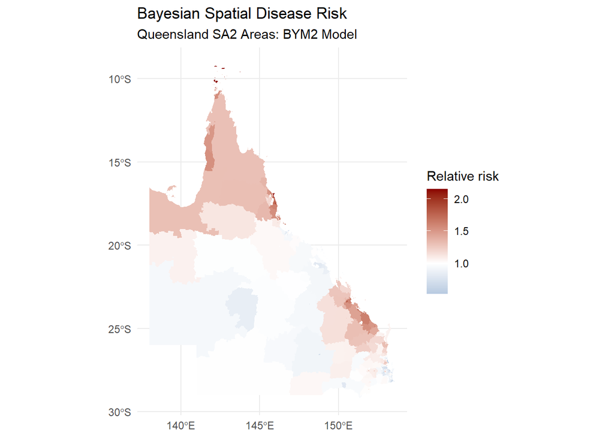

```r
print(
  ggplot(qld) +
    geom_sf(
      aes(fill = RR_BAYES),
      colour = NA
    ) +
    scale_fill_gradient2(
      low = "steelblue",
      mid = "white",
      high = "darkred",
      midpoint = 1,
      name = "Relative risk"
    ) +
    labs(
      title = "Bayesian Spatial Disease Risk",
      subtitle = "Queensland SA2 Areas: BYM2 Model"
    ) +
    theme_minimal()
)
```

**Example:** In the earlier output, Bouldercombe changed from crude ratio **2.36** to smoothed Bayesian RR **1.53**.

## 4.10 Compare crude and Bayesian risk

Compare crude and smoothed risk maps using a shared colour scale. Differences illustrate the effect of modelling and spatial smoothing.

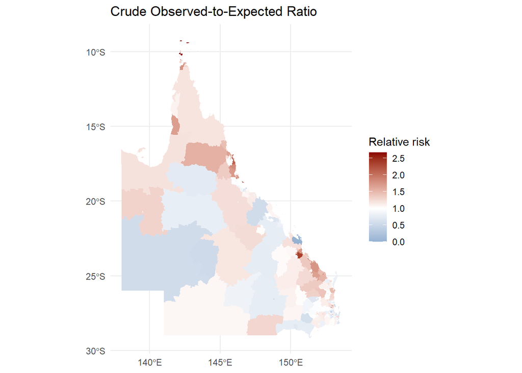

```r
# Use the same colour limits for both maps
# so students can compare them meaningfully.

common_max <- max(qld$SIR, qld$RR_BAYES, na.rm = TRUE)
# Keep the reference value 1 at the colour midpoint on both maps.
# A shared scale permits direct comparison; extreme crude SIRs may
# compress visual differences, which is a useful discussion point.

print(
  ggplot(qld) +
    geom_sf(aes(fill = SIR), colour = NA) +
    scale_fill_gradient2(
      low = "steelblue",
      mid = "white",
      high = "darkred",
      midpoint = 1,
      limits = c(0, common_max),
      name = "Relative risk"
    ) +
    labs(
      title = "Crude Observed-to-Expected Ratio"
    ) +
    theme_minimal()
)
```

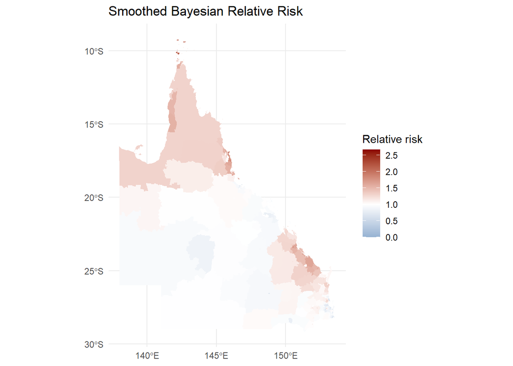

```r
print(
  ggplot(qld) +
    geom_sf(aes(fill = RR_BAYES), colour = NA) +
    scale_fill_gradient2(
      low = "steelblue",
      mid = "white",
      high = "darkred",
      midpoint = 1,
      limits = c(0, common_max),
      name = "Relative risk"
    ) +
    labs(
      title = "Smoothed Bayesian Relative Risk"
    ) +
    theme_minimal()
)
```

**Caution:** A shared scale may reduce contrast in the smoothed map if a crude outlier is very high. A sensitivity map with capped display values may help, but should be clearly labelled.

## 4.11 Classify areas by posterior credible interval

A central 95% credible interval entirely above 1 supports elevated risk; entirely below 1 supports reduced risk. Otherwise the direction remains uncertain at this threshold.

```r
qld$RISK_CLASS <- ifelse(
  qld$RR_LOWER > 1,
  "Higher risk",
  ifelse(
    qld$RR_UPPER < 1,
    "Lower risk",
    "Uncertain"
  )
)

# Display the corrected number of SA2 areas
print(table(qld$RISK_CLASS))
```

```
Higher risk  Lower risk   Uncertain
         96         106         331
```

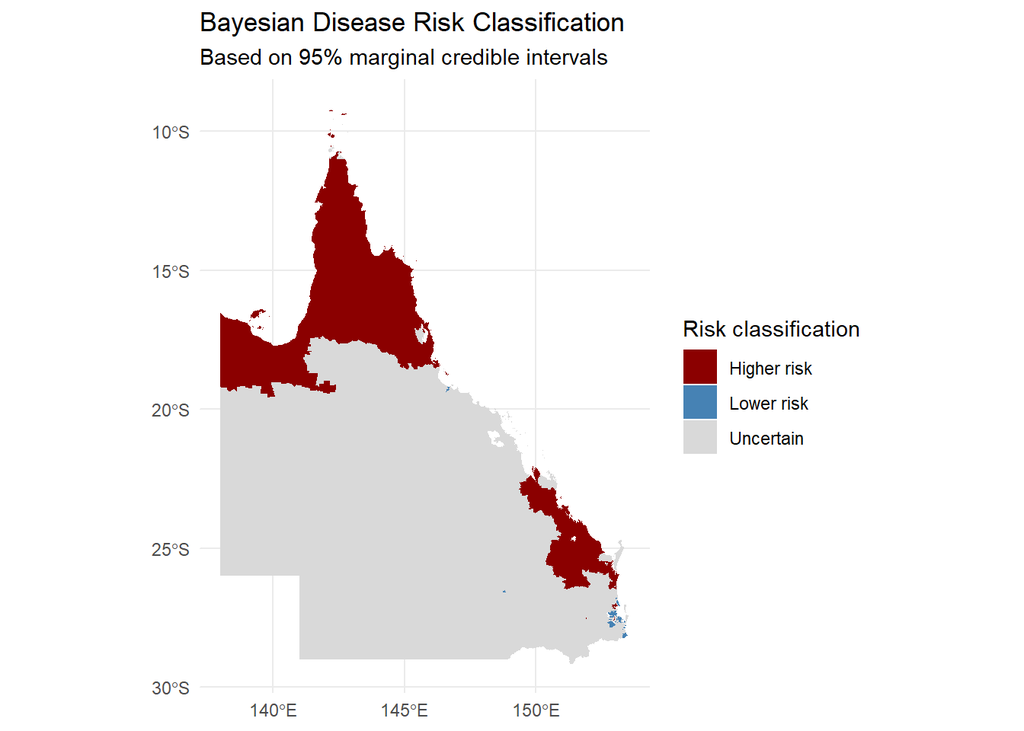

```r
# Map classifications
print(
  ggplot(qld) +
    geom_sf(
      aes(fill = RISK_CLASS),
      colour = NA
    ) +
    scale_fill_manual(
      values = c(
        "Higher risk" = "darkred",
        "Lower risk" = "steelblue",
        "Uncertain" = "grey85"
      ),
      name = "Risk classification"
    ) +
    labs(
      title = "Bayesian Disease Risk Classification",
      subtitle = "Based on 95% marginal credible intervals"
    ) +
    theme_minimal()
)
```

**Reproducibility note:** The figures below are reference values from one successful run, not exact values students must reproduce to every decimal place. INLA versions, numerical optimisation settings and computing environments can lead to small differences in posterior summaries and information criteria. Students should focus on the direction, magnitude and interpretation of results; substantial discrepancies should be investigated.

**Expected result from the supplied teaching dataset:** **96 higher**, **106 lower**, **331 uncertain**. These are marginal interval decisions and do not adjust for 533 simultaneous comparisons.

## 4.12 Save corrected results

Save the fitted models and the corrected spatial results for reproducibility and subsequent GIS use.

```r
saveRDS(
  qld,
  "QLD_SA2_Session4_Bayesian_Results.rds"
)

st_write(
  qld,
  "QLD_SA2_Bayesian_Results.gpkg",
  delete_dsn = TRUE,
  quiet = TRUE
)

cat("\nCORRECTED BAYESIAN RESULTS SAVED SUCCESSFULLY!\n")
```

```
CORRECTED BAYESIAN RESULTS SAVED SUCCESSFULLY!
```

```r
# SESSION 4: BAYESIAN SPATIAL DISEASE MAPPING IN R

saveRDS(model_m1, "QLD_SA2_Model1_Poisson.rds")
saveRDS(model_m2, "QLD_SA2_Model2_IID.rds")
saveRDS(model_m3, "QLD_SA2_Model3_BYM2.rds")
write.csv(model_comparison, "QLD_SA2_Model_Comparison.csv", row.names = FALSE)
```

**Practical note:** Close a GeoPackage in QGIS if Windows prevents it being overwritten.

# Section 5: Exceedance probabilities and uncertainty

This section asks how certain we are that risk exceeds 1, not only what its posterior mean is.

## 5.1 Load packages and existing results

Continue directly with the model fitted in Section 4.5. The posterior marginals are now available because the correct INLA setting was included there.

```r
# Continue directly from Section 4: qld and model_m3 are already in memory.
stopifnot(
  nrow(model_m3$summary.fitted.values) == nrow(qld),
  length(model_m3$marginals.fitted.values) == nrow(qld)
)
summary(qld$RR_BAYES)
```

```
   Min. 1st Qu.  Median    Mean 3rd Qu.    Max.
 0.5243  0.8496  0.9644  1.0300  1.1225  2.1543
```

**Check:** The number of fitted-value marginal distributions must equal **533**.

## 5.2 Calculate posterior exceedance probabilities

An exceedance probability is $P(\theta_i>1\mid\mathrm{data})$: the posterior probability that area-level relative risk exceeds the reference value 1.

```r
# Exceedance probability is:
# P(Relative Risk > 1 | Data)
#
# Values close to 1 indicate strong evidence of elevated risk.
# Values close to 0 indicate strong evidence of reduced risk.
# Values near 0.5 indicate uncertainty about the direction.

# INLA provides marginal posterior distributions
# for fitted relative risks.

# Check that the marginal distributions are available
if (length(model_m3$marginals.fitted.values) != nrow(qld)) {
  stop("Missing posterior marginals: set return.marginals.predictor = TRUE ",
       "inside control.compute in the BYM2 fit (Section 4.5).")
}

# Calculate P(RR > 1) for every SA2
qld$PROB_RR_GT1 <- vapply(
  model_m3$marginals.fitted.values,
  function(marginal) {
    1 - INLA::inla.pmarginal(1, marginal)
  },
  numeric(1)
)

# Check the range
summary(qld$PROB_RR_GT1)
```

```
   Min. 1st Qu.  Median    Mean 3rd Qu.    Max.
 0.0000  0.0478  0.3494  0.4390  0.8678  1.0000
```

```r
# All probabilities should be between 0 and 1
stopifnot(
  all(is.finite(qld$PROB_RR_GT1)),
  all(qld$PROB_RR_GT1 >= 0),
  all(qld$PROB_RR_GT1 <= 1)
)

# Display examples
print(
  qld %>%
    st_drop_geometry() %>%
    select(
      SA2_NAME,
      SIR,
      RR_BAYES,
      RR_LOWER,
      RR_UPPER,
      PROB_RR_GT1
    ) %>%
    head(10)
)
```

```
                  SA2_NAME       SIR  RR_BAYES  RR_LOWER  RR_UPPER  PROB_RR_GT1
1  North Stradbroke Island 0.6685344 0.9176705 0.6196350 1.3080753 2.917229e-01
2                 McDowall 0.6698407 0.6876414 0.5675971 0.8249804 2.844496e-05
3    Eagle Farm - Pinkenba 0.6961782 0.7246470 0.4968268 1.0207039 3.206388e-02
4          Macgregor (Qld) 0.9644503 0.9215412 0.7435415 1.1290169 2.048946e-01
5                  Taringa 0.7971043 0.8559799 0.6738448 1.0718131 8.427729e-02
6                  Wilston 1.0746580 0.9091518 0.7106215 1.1473544 1.989880e-01
7                 Daintree 1.4501127 1.3599049 1.0833484 1.6861361 9.962162e-01
8                Herberton 1.3589371 1.3427212 1.1169785 1.6006230 9.991870e-01
9                  Balonne 1.2822354 1.0365760 0.8144249 1.3010369 5.945012e-01
10            Bouldercombe 2.3605104 1.5304052 1.2676029 1.8345332 9.999997e-01
```

**Examples:** Daintree ≈ **0.9962**; Balonne ≈ **0.5945**; McDowall ≈ **0.000028**. Values printed as exactly 0 or 1 may reflect numerical precision, not absolute certainty.

## 5.3 Map posterior exceedance probabilities

A probability map visualises the **strength of posterior evidence** for elevated risk, rather than the estimated magnitude of risk.

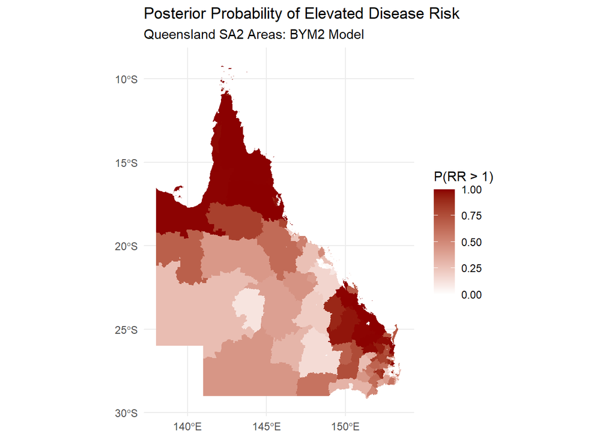

```r
# Darker colours indicate greater probability
# that the relative risk exceeds 1.

print(
  ggplot(qld) +
    geom_sf(
      aes(fill = PROB_RR_GT1),
      colour = NA
    ) +
    scale_fill_gradient(
      low = "white",
      high = "darkred",
      limits = c(0, 1),
      name = "P(RR > 1)"
    ) +
    labs(
      title = "Posterior Probability of Elevated Disease Risk",
      subtitle = "Queensland SA2 Areas: BYM2 Model"
    ) +
    theme_minimal()
)
```

**Question:** Can an SA2 have RR = 1.3 but a less convincing exceedance probability than another SA2 with RR = 1.2? Explain using uncertainty.

## 5.4 Classify areas using exceedance probabilities

Use one-sided thresholds: above 0.95 for evidence of elevated risk, below 0.05 for evidence of reduced risk, and otherwise uncertain. **These are illustrative marginal thresholds, not a multiplicity-adjusted decision rule for simultaneously selecting 533 priority areas.** Interpret the resulting map as a teaching exercise, not as a definitive public-health prioritisation list.

```r
# Thresholds used for teaching:
#
# P(RR > 1) > 0.95: Strong evidence of elevated risk
# P(RR > 1) < 0.05: Strong evidence of reduced risk
# Otherwise: Uncertain

qld$PROB_CLASS <- ifelse(
  qld$PROB_RR_GT1 > 0.95,
  "Higher risk",
  ifelse(
    qld$PROB_RR_GT1 < 0.05,
    "Lower risk",
    "Uncertain"
  )
)

# Display number of SA2 areas in each category
print(table(qld$PROB_CLASS))
```

```
Higher risk  Lower risk   Uncertain
        110         138         285
```

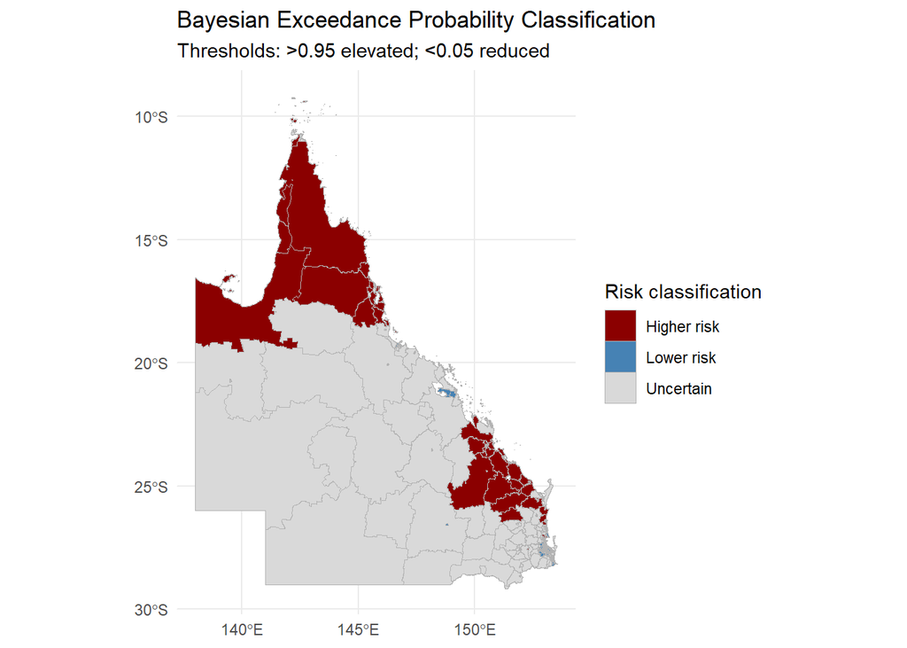

```r
# Map probability-based risk classification
print(
  ggplot(qld) +
    geom_sf(
      aes(fill = PROB_CLASS),
      colour = "grey70",
      linewidth = 0.05
    ) +
    scale_fill_manual(
      values = c(
        "Higher risk" = "darkred",
        "Lower risk" = "steelblue",
        "Uncertain" = "grey85"
      ),
      name = "Risk classification"
    ) +
    labs(
      title = "Bayesian Exceedance Probability Classification",
      subtitle = "Thresholds: >0.95 elevated; <0.05 reduced"
    ) +
    theme_minimal()
)
```

**Reproducibility note:** The figures below are reference values from one successful run, not exact values students must reproduce to every decimal place. INLA versions, numerical optimisation settings and computing environments can lead to small differences in posterior summaries and information criteria. Students should focus on the direction, magnitude and interpretation of results; substantial discrepancies should be investigated.

**Expected result from the supplied teaching dataset:** **110 higher**, **138 lower**, **285 uncertain**. These thresholds are illustrative, not a joint or multiplicity-adjusted decision rule.

## 5.5 Map posterior uncertainty

The posterior standard deviation measures **absolute uncertainty** in estimated relative risk. Larger SD indicates less precise estimates.

```r
# Posterior standard deviation measures uncertainty
# in the estimated relative risk.
#
# Higher values indicate less precise estimates.

qld$RR_SD <- model_m3$summary.fitted.values$sd

# Summarise uncertainty
summary(qld$RR_SD)
```

```
   Min. 1st Qu.  Median    Mean 3rd Qu.    Max.
0.05492 0.08201 0.09751 0.10627 0.11925 0.31480
```

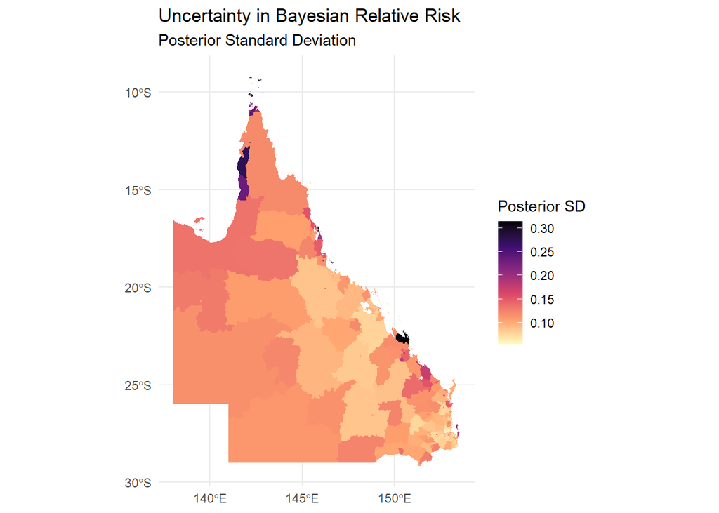

```r
# Map posterior standard deviation
print(
  ggplot(qld) +
    geom_sf(
      aes(fill = RR_SD),
      colour = NA
    ) +
    scale_fill_viridis_c(
      option = "magma",
      direction = -1,
      name = "Posterior SD"
    ) +
    labs(
      title = "Uncertainty in Bayesian Relative Risk",
      subtitle = "Posterior Standard Deviation"
    ) +
    theme_minimal()
)
```

**Reproducibility note:** The figures below are reference values from one successful run, not exact values students must reproduce to every decimal place. INLA versions, numerical optimisation settings and computing environments can lead to small differences in posterior summaries and information criteria. Students should focus on the direction, magnitude and interpretation of results; substantial discrepancies should be investigated.

**Expected result from the supplied teaching dataset:** Median SD ≈ **0.0975**; range **0.0549–0.3148**. Absolute SD also depends on RR magnitude, so comparisons deserve care.

## 5.6 Examine uncertainty and population size

Plot posterior SD against SA2 population and calculate Spearman rank correlation. This checks whether larger populations tend to have more precise estimates.

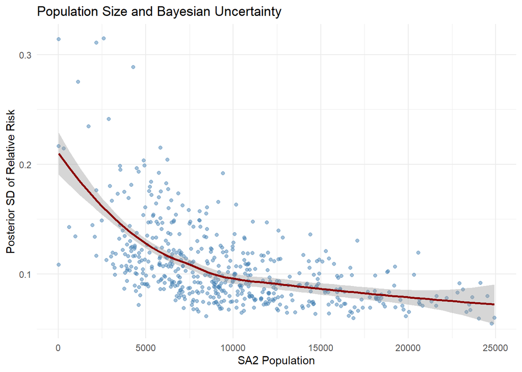

```r
# Small-population areas often have less precise estimates,
# although spatial borrowing of information can modify this.

# Scatterplot of population against posterior SD
print(
  ggplot(
    st_drop_geometry(qld),
    aes(
      x = POPULATION,
      y = RR_SD
    )
  ) +
    geom_point(
      colour = "steelblue",
      alpha = 0.5
    ) +
    geom_smooth(
      method = "loess",
      se = TRUE,
      colour = "darkred"
    ) +
    labs(
      title = "Population Size and Bayesian Uncertainty",
      x = "SA2 Population",
      y = "Posterior SD of Relative Risk"
    ) +
    theme_minimal()
)
```

```r
# Calculate Spearman correlation
cor.test(
  qld$POPULATION,
  qld$RR_SD,
  method = "spearman",
  exact = FALSE
)
```

```
    Spearman's rank correlation rho

data:  qld$POPULATION and qld$RR_SD
S = 40249186, p-value < 2.2e-16
alternative hypothesis: true rho is not equal to 0
sample estimates:
       rho
-0.5948809
```

**Reproducibility note:** The figures below are reference values from one successful run, not exact values students must reproduce to every decimal place. INLA versions, numerical optimisation settings and computing environments can lead to small differences in posterior summaries and information criteria. Students should focus on the direction, magnitude and interpretation of results; substantial discrepancies should be investigated.

**Expected result from the supplied teaching dataset:** Spearman $\rho\approx-0.595$, $p<2.2\times10^{-16}$. This is an association, not proof that population alone causes the uncertainty pattern.

## 5.7 Identify areas with strong evidence of high risk

Rank SA2s by exceedance probability to identify examples with strong posterior evidence of elevated risk.

```r
# Display the 10 areas with the highest
# posterior probability of elevated risk.

high_risk_areas <- qld %>%
  st_drop_geometry() %>%
  arrange(desc(PROB_RR_GT1)) %>%
  select(
    SA2_NAME,
    POPULATION,
    CASES,
    SIR,
    RR_BAYES,
    PROB_RR_GT1
  ) %>%
  head(10)

print(high_risk_areas)
```

```
                      SA2_NAME POPULATION CASES      SIR RR_BAYES PROB_RR_GT1
1           Caboolture - South      24123   140 1.416810 1.362918   0.9999997
2      Bargara - Burnett Heads      19243   124 1.573127 1.476920   0.9999997
3                     Redlynch      14015    89 1.550286 1.563697   0.9999997
4         Gladstone Hinterland      11671    66 1.380546 1.454207   0.9999997
5                      Yeppoon      20575   132 1.566206 1.556789   0.9999997
6  Bundaberg Surrounds - South      10872    68 1.526913 1.413707   0.9999997
7               Norman Gardens      10828    59 1.330205 1.462461   0.9999997
8       Clinton - New Auckland      14413   103 1.744607 1.715935   0.9999997
9        Kanimbla - Mooroobool      10085    78 1.888137 1.712780   0.9999997
10  Trinity Beach - Smithfield      17097   113 1.613516 1.619355   0.9999997
```

**Important:** Values near 1 often tie numerically; the first ten listed are not necessarily the ten largest **risk magnitudes**. Use RR and uncertainty alongside the probability.

## 5.8 Identify areas with strong evidence of low risk

Rank SA2s by low exceedance probability to identify areas with strong posterior evidence of reduced risk.

```r
low_risk_areas <- qld %>%
  st_drop_geometry() %>%
  arrange(PROB_RR_GT1) %>%
  select(
    SA2_NAME,
    POPULATION,
    CASES,
    SIR,
    RR_BAYES,
    PROB_RR_GT1
  ) %>%
  head(10)

print(low_risk_areas)
```

```
                         SA2_NAME POPULATION CASES       SIR  RR_BAYES
1                 Alexandra Hills      16878    36 0.5207106 0.6798204
2               Currumbin - Tugun      12493    20 0.3908212 0.5243165
3                      Palm Beach      16606    38 0.5586418 0.6144939
4                  Wavell Heights      10474    18 0.4195414 0.6044554
5            Northgate - Virginia       7169    12 0.4086369 0.6119993
6                   Bribie Island      20820    38 0.4455719 0.5811415
7              The Hills District      24782    73 0.7191200 0.7123591
8  Augustine Heights - Brookwater       9137    18 0.4809321 0.6199797
9                          Nundah      13552    32 0.5764498 0.6800599
10                       McDowall       8018    22 0.6698407 0.6876414
    PROB_RR_GT1
1  0.000000e+00
2  0.000000e+00
3  0.000000e+00
4  0.000000e+00
5  0.000000e+00
6  0.000000e+00
7  0.000000e+00
8  4.189873e-06
9  1.111408e-05
10 2.844496e-05
```

**Interpretation:** A low probability of RR > 1 is not the same as zero disease burden.

## 5.9 Compare credible-interval and exceedance classifications

Compare central 95% credible-interval classification with one-sided 0.95/0.05 exceedance thresholds. They need not agree because the thresholds differ.

```r
# Section 4 used 95% credible intervals.
# Section 5 uses posterior probability thresholds.
#
# They need not classify exactly the same areas because
# the thresholds are not equivalent.

print(
  table(
    Credible_Interval = qld$RISK_CLASS,
    Exceedance_Probability = qld$PROB_CLASS
  )
)
```

```
                 Exceedance_Probability
Credible_Interval Higher risk Lower risk Uncertain
      Higher risk          96          0         0
      Lower risk            0        106         0
      Uncertain            14         32       285
```

**Reproducibility note:** The figures below are reference values from one successful run, not exact values students must reproduce to every decimal place. INLA versions, numerical optimisation settings and computing environments can lead to small differences in posterior summaries and information criteria. Students should focus on the direction, magnitude and interpretation of results; substantial discrepancies should be investigated.

**Expected result from the supplied teaching dataset:** All **202** areas classified higher/lower by central 95% intervals kept their class; exceedance thresholds additionally classified **14 higher** and **32 lower**.

## 5.10 Save results

Save the complete Section 5 dataset and ranked CSVs. The GeoPackage can be opened directly in QGIS for further exploration.

```r
# Save complete dataset
saveRDS(
  qld,
  "QLD_SA2_Session5_Bayesian_Results.rds"
)

# Save spatial layer for QGIS
st_write(
  qld,
  "QLD_SA2_Session5_Bayesian_Results.gpkg",
  delete_dsn = TRUE,
  quiet = TRUE
)

# Save high-risk areas
write.csv(
  high_risk_areas,
  "QLD_SA2_High_Risk_Areas.csv",
  row.names = FALSE
)

# Save low-risk areas
write.csv(
  low_risk_areas,
  "QLD_SA2_Low_Risk_Areas.csv",
  row.names = FALSE
)

cat(
  "\nSECTION 5 COMPLETED SUCCESSFULLY!\n"
)
```

```
SECTION 5 COMPLETED SUCCESSFULLY!
```

**Output:** An RDS file, a GeoPackage, and two CSV tables of high- and low-exceedance areas.

# Final teaching synthesis

### Model comparison and spatial interpretation

The Poisson model assumes that IRSD explains systematic variation and that no additional area-level random effects are needed. The IID model allows unexplained differences among SA2s but does not use neighbourhood information. BYM2 adds a structured component, allowing neighbouring areas to share information, while retaining an unstructured component. The fitted BYM2 spatial mixing parameter was approximately **0.985** in the earlier run, indicating a high share of latent variation allocated to the structured component **under this model and its priors**. It does not mean that 98.5% of disease cases are caused by geography.

### Suggested discussion questions

1. Why can a crude observed-to-expected ratio be extreme when expected counts are small?
2. Why do the seven island SA2s require special attention in a contiguity-based spatial model?
3. How does the IRSD effect change between the Poisson and BYM2 models, and what could explain this?
4. Why is a posterior RR of 1.3 not enough, by itself, to conclude that an area has elevated risk?
5. Why do one-sided 0.95 exceedance thresholds classify more areas than central 95% credible intervals?
6. What limitations arise from ecological data, population-based expected counts, spatial confounding and the chosen adjacency structure?

### Practical limitations and extensions

- **No demographic standardisation:** Age- and sex-specific reference rates would be required for a conventional standardised incidence ratio.
- **No spatial sensitivity analysis:** Queen versus rook or distance-based neighbours could be compared in a later exercise.
- **No external prediction assessment:** DIC and WAIC are not a substitute for independent or spatially blocked validation.
- **No multiplicity adjustment:** The risk classifications are marginal, area-by-area summaries.
- **No causal interpretation:** IRSD is ecological and may be correlated with omitted factors.
- **No temporal modelling:** This tutorial analyses spatial variation only.

**End of Session 4.**